# Applied Stats Module 0 Project- 2024 GAC Softball Hitting Statistics

# Module 4

One way- Averages of Teams Null Hypothesis: True mean of averages for each team are equal. Alternative: True mean of averages for each team are not equal.

```r
results<- aov(AVG~Team, data=df)
summary(results)
```

```
##              Df Sum Sq Mean Sq F value Pr(>F)
## Team         11  0.285 0.02592   1.261  0.248
## Residuals   247  5.078 0.02056
```

We fail to reject the null hypothesis, thus the true mean of averages for each team are equal.

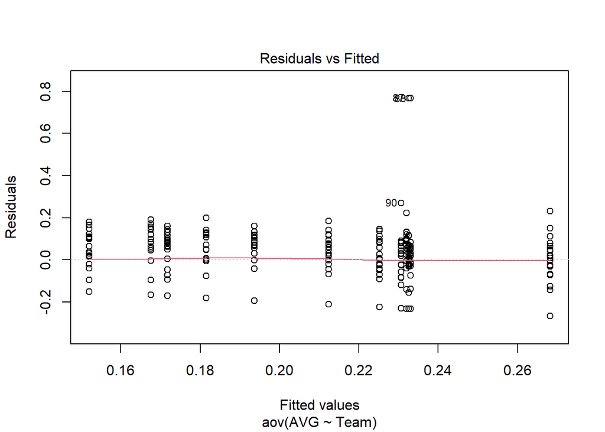

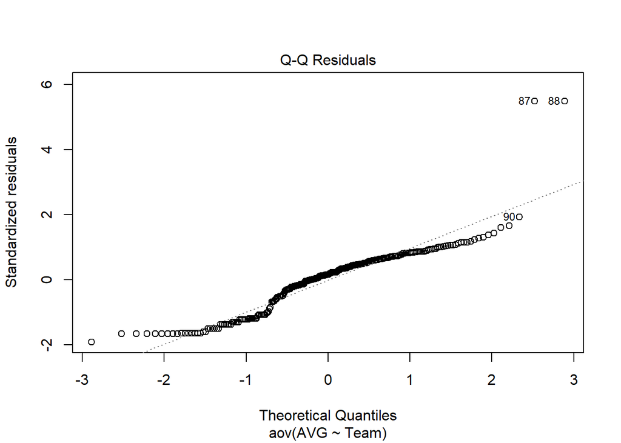

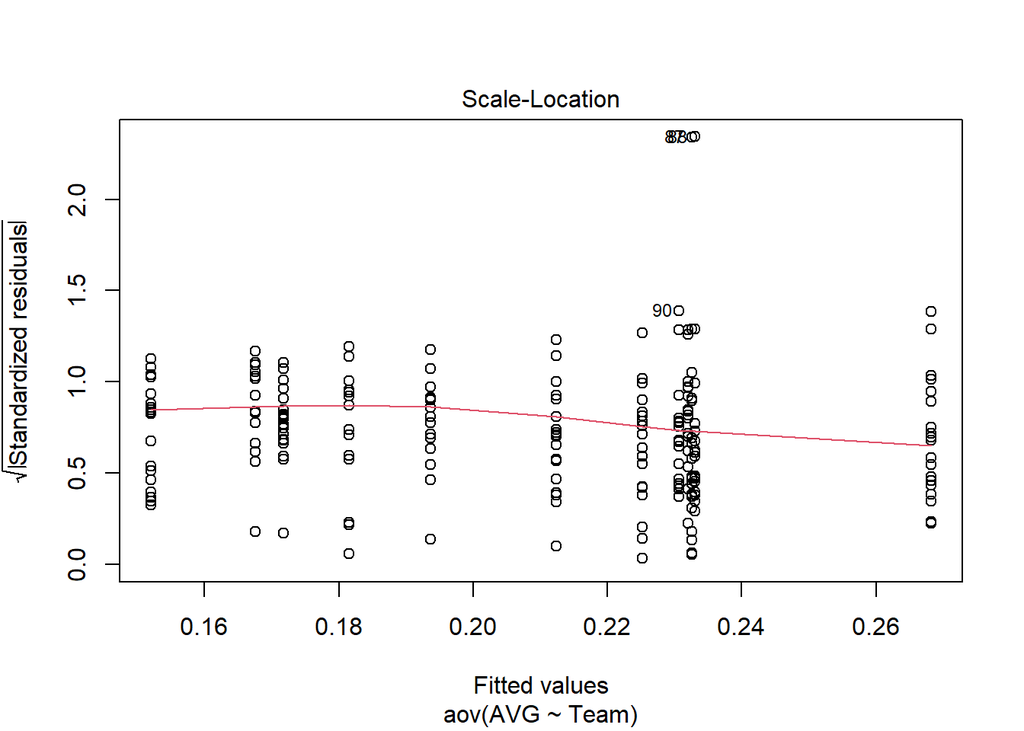

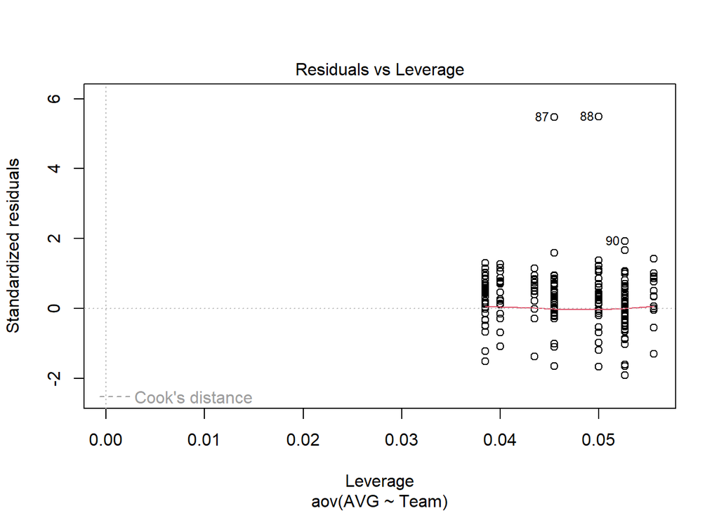

```r
plot(results)
```

Residual variance isn’t great but also isn’t bad.

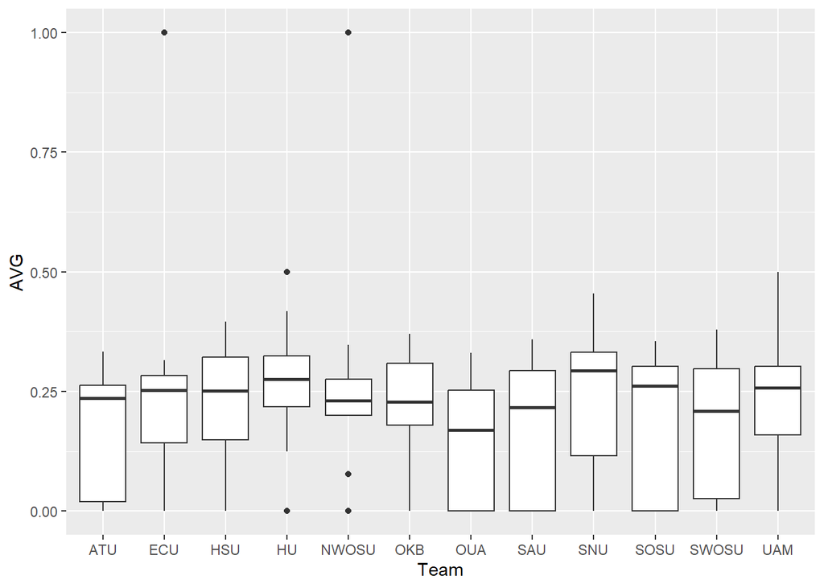

```r
ggplot(df, aes(y=AVG, x=Team))+
  geom_boxplot()
```

two way- Averages of starters and non starters on a team Null hypothesis: Mean of averages of Starters is equal to mean of averages of non-starters on each team. Alternative hypothesis: Mean of averages of starters is not equal to mean of averages of non-starters on each team.

```r
result<- aov(AVG~Team*Starters, data=df)
summary(result)
```

```
##                Df Sum Sq Mean Sq F value   Pr(>F)
## Team           11  0.285  0.0259   1.628   0.0916 .
## Starters        1  0.999  0.9986  62.723 9.44e-14 ***
## Team:Starters  11  0.338  0.0307   1.931   0.0364 *
## Residuals     235  3.741  0.0159
## ---
## Signif. codes:  0 '***' 0.001 '**' 0.01 '*' 0.05 '.' 0.1 ' ' 1
```

Reject null on two way table, being a starter makes a difference and teams and starters makes a difference.

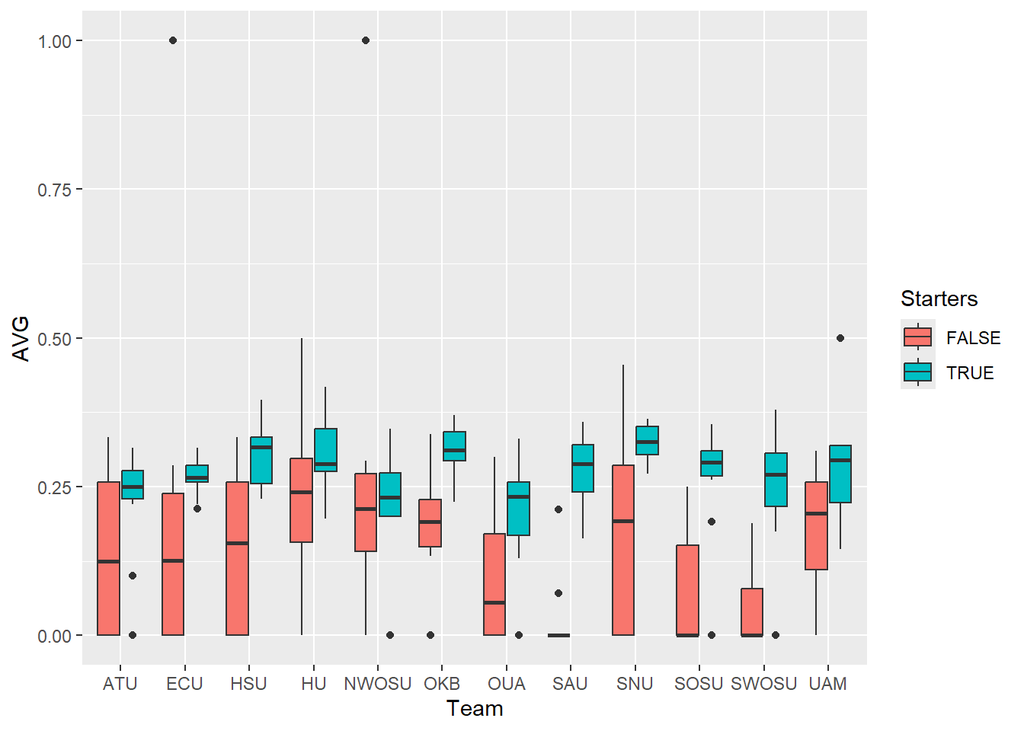

```r
ggplot(df, aes(y=AVG, x=Team, fill=Starters))+
  geom_boxplot()
```

You can really see the difference being a starter makes here.

kruskal-wallis (anova but with median) and spearman rank correlation (module 1)

# Module 5

Alrighty, for module 5 I will be first be performing the kruskal-wallis test on the same thing I did for my one-way anova test, but I will be using the non-parametric statistic, median, instead of mean.

Null Hypothesis: Median of averages for each team are equal. Alternative Hypothesis: Median of averages for each team are not equal.

First, lets look at the boxplot.

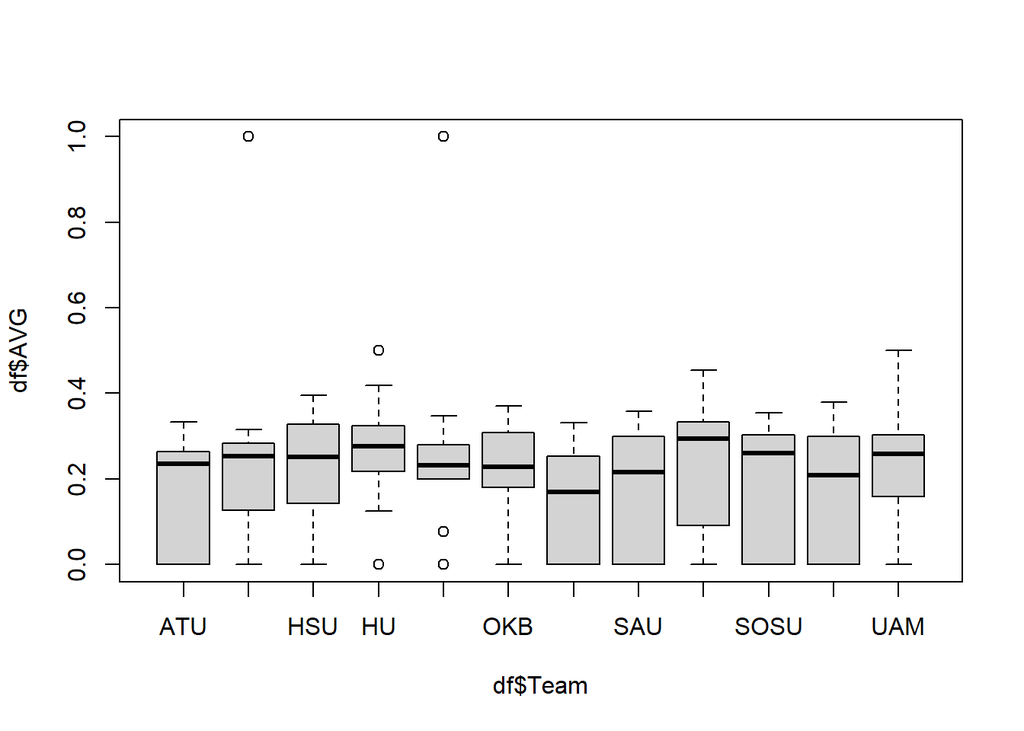

```r
boxplot(df$AVG ~ df$Team)
```

Harding and SNU have two of the highest team batting averages, and they were ranked highly in the conference, so it makes sense that they are up there.

Now lets look at the median batting averages for each team.

```r
by(df$AVG,df$Team, median)
```

```
## df$Team: ATU
## [1] 0.2355
## ------------------------------------------------------------
## df$Team: ECU
## [1] 0.2525
## ------------------------------------------------------------
## df$Team: HSU
## [1] 0.251
## ------------------------------------------------------------
## df$Team: HU
## [1] 0.276
## ------------------------------------------------------------
## df$Team: NWOSU
## [1] 0.231
## ------------------------------------------------------------
## df$Team: OKB
## [1] 0.228
## ------------------------------------------------------------
## df$Team: OUA
## [1] 0.169
## ------------------------------------------------------------
## df$Team: SAU
## [1] 0.2165
## ------------------------------------------------------------
## df$Team: SNU
## [1] 0.2935
## ------------------------------------------------------------
## df$Team: SOSU
## [1] 0.261
## ------------------------------------------------------------
## df$Team: SWOSU
## [1] 0.2085
## ------------------------------------------------------------
## df$Team: UAM
## [1] 0.258
```

Looks about right.

Now we run our test

```r
kruskal.test(AVG ~ Team , data = df)
```

```
##
##  Kruskal-Wallis rank sum test
##
## data:  AVG by Team
## Kruskal-Wallis chi-squared = 15.662, df = 11, p-value = 0.1541
```

We got a pretty high p-value, thus we fail to reject our null hypothesis. So, the median of averages for each team are equal. We got the same result when looking at the means.

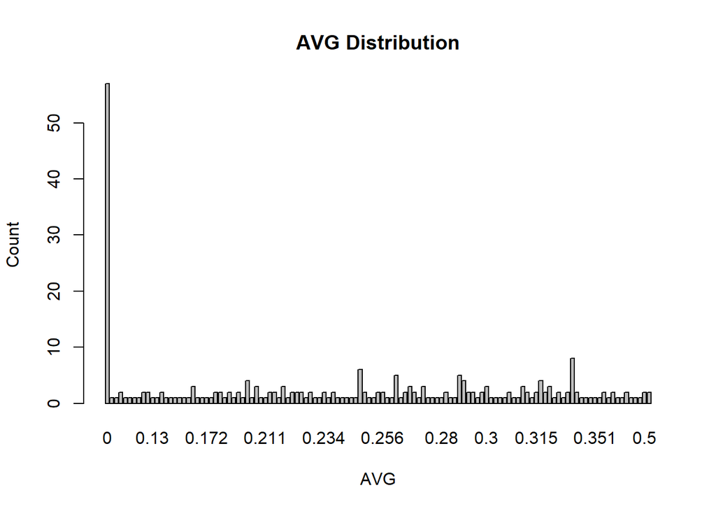

```r
barplot(table(df$AVG),
        main = "AVG Distribution",
        xlab = "AVG", ylab = "Count")
```

Not normal

I think the kruskal wallis test was the better way to go because the data did not have normal distribution, nor could I guarantee equal variance across the groups. And in this case since all the data is pretty close together and there is a lot of it, the medians probably don’t lie very far from the means anyways.

Okayyyy, now onto the Spearman rank correlation test. I will perform the test on the same thing that I did in module 1, that is, do hits relate to avg. SPOILER ALERT, THEY DO!

But anyways here we go.

```r
cor.test(df$Hits, df$AVG, method = "spearman")
```

```
##
##  Spearman's rank correlation rho
##
## data:  df$Hits and df$AVG
## S = 616023, p-value < 2.2e-16
## alternative hypothesis: true rho is not equal to 0
## sample estimates:
##      rho
## 0.787257
```

We reject the null hypothesis- very low p-value

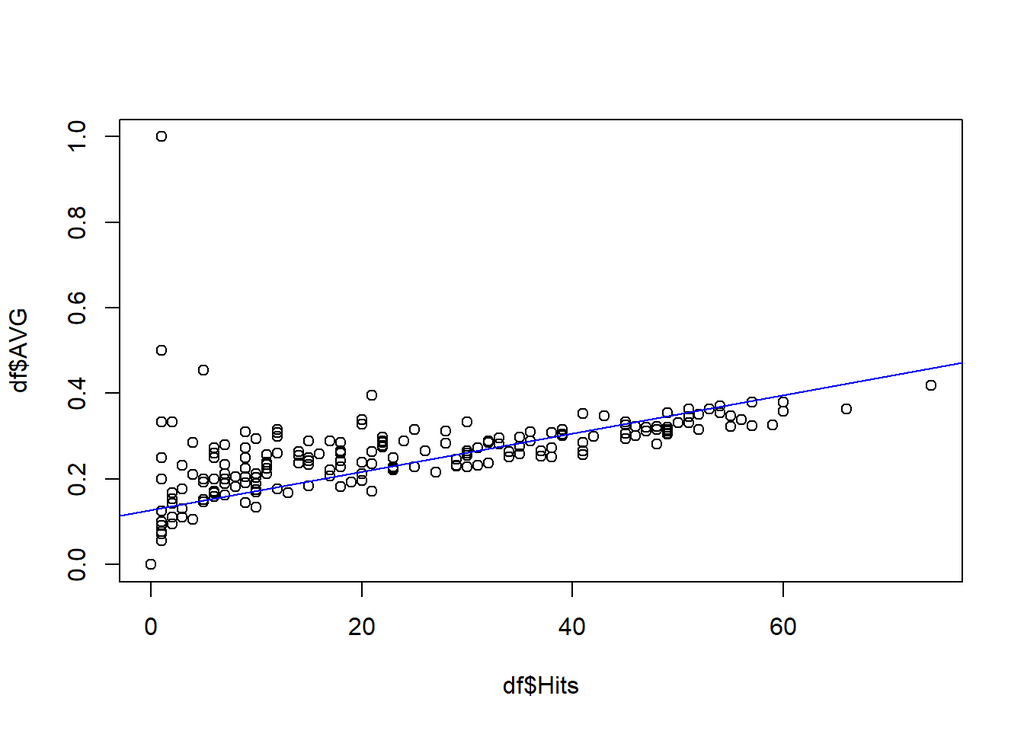

```r
plot(df$Hits, df$AVG)
abline(lm(AVG ~ Hits, data = df),col = "Blue")
```

Obviously we get a very positive, strong correlation. Hits do relate to AVG.

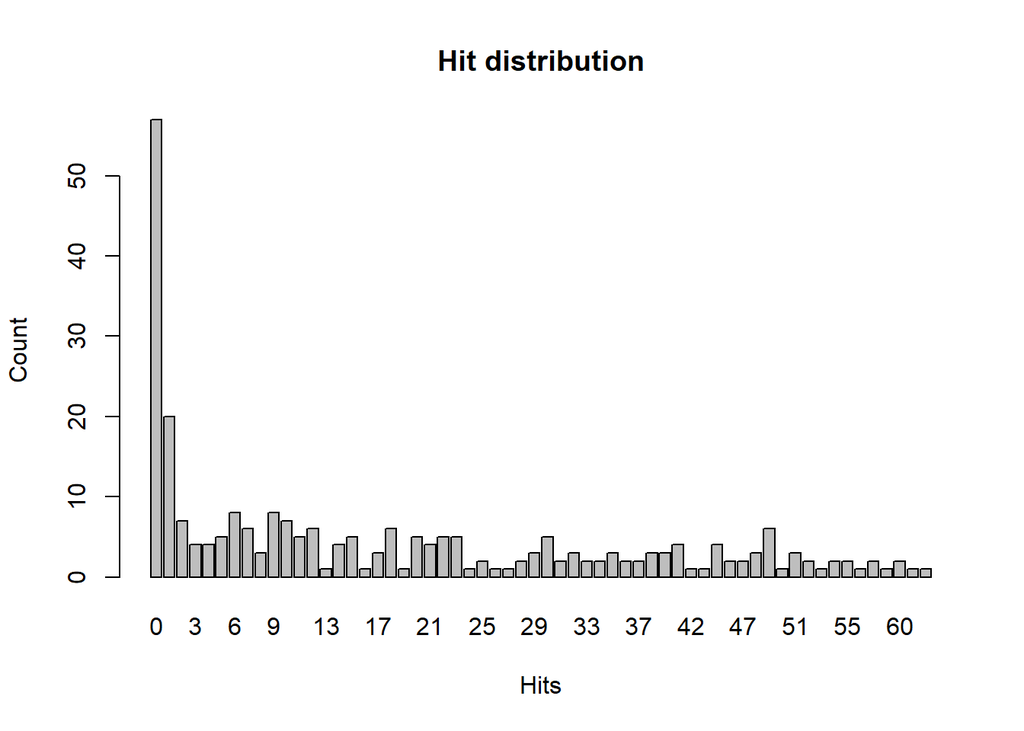

```r
barplot(table(df$Hits),
        main = "Hit distribution",
        xlab = "Hits", ylab = "Count")
```

Obviously not normal

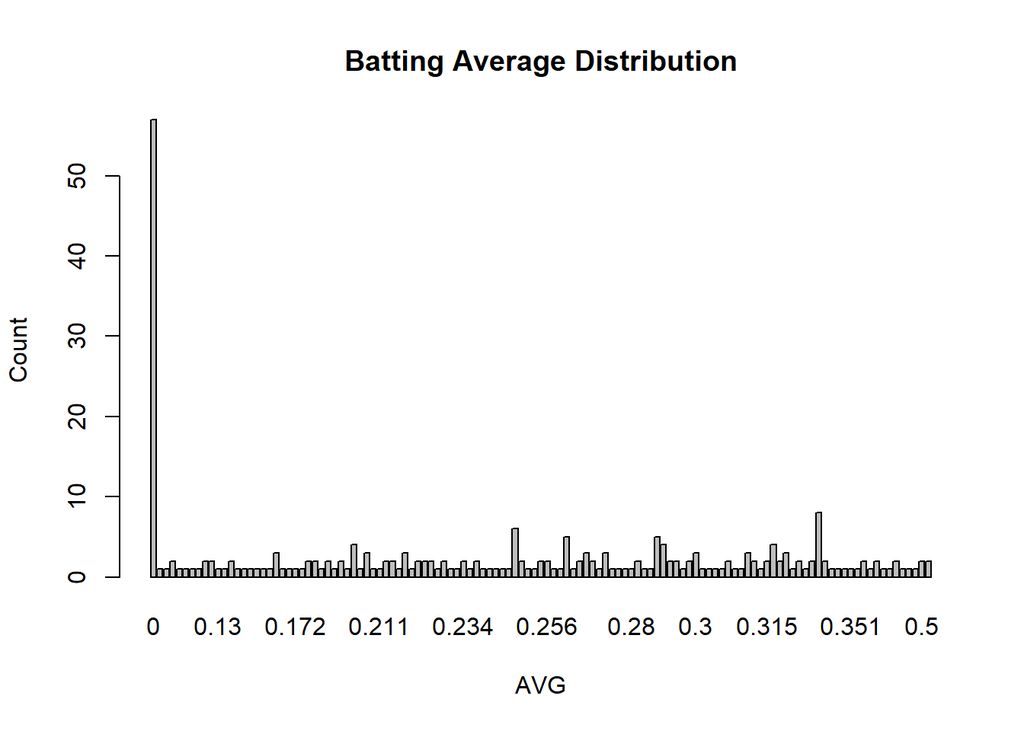

```r
barplot(table(df$AVG),
        main = "Batting Average Distribution",
        xlab = "AVG", ylab = "Count")
```

Not normal

Also, neither distributions of are normal because of the outliers in the data, so spearman is a better test.